# How Older Adults Spent Their Time for Social Engagement During Covid-19

American Time Use Survey (ATUS) - Data Visualization

Jiao Yu

2/3/2023

```r
library(foreign)
library(psych)
library(dplyr)
library(tidyr)
library(ggplot2)
library(ggpubr)
library(egg)
library(survey)
library(forcats)
library(egg)
library(lubridate)
```

Let’s take a quick look at our data. We have ATUS data from 2019 to 2021. ATUS, initiated in 2003, employs a computer-assisted telephone interview method to collect information from a nationally representative sample of the U.S. noninstitutionalized population. One individual aged at least 15 years old in each selected household retrospectively reported daily activities and corresponding time intervals throughout the 24 hours. Data contain basic demographic information and time (in minutes) spent on each of the following activities:

1. volunteer activities
2. religious and spiritual activities
3. civic obligations and education-related activities
4. social, relaxing, and leisure activities
5. telephone calls

```r
ATUS<-read.dta("/Users/jiaoyu/Documents/Ph.D/projects/ATUS/data/atus_R.dta",convert.factors = F)
head(ATUS)
```

```
##   year      caseid region statefip county hh_numkids month age engage engage_n
## 1 2019 2.01901e+13      3       48  48000          0     1  85      0        0
## 2 2019 2.01901e+13      2       26  26000          1     1  25      0        0
## 3 2019 2.01901e+13      1       36  36047          0     1  20      0        0
## 4 2019 2.01901e+13      1       36  36005          0     1  61      0        0
## 5 2019 2.01901e+13      1       50  50000          1     1  34     55       55
## 6 2019 2.01901e+13      1       25  25017          0     1  53    192      192
##   volunteer_h2 volunteer_nh2 religion_h2 religion_nh2 civic_h2 civic_nh2
## 1            0             0           0          240        0         0
## 2            0             0           0            0        0         0
## 3            0             0           0            0        0         0
## 4            0             0           0            0        0         0
## 5            0             0           0            0        0         0
## 6           90            20           0            0        0         0
##   social_leisure_nh2 social_leisure_h2 education_nh2 education_h2 phone_h2
```

[output cut: 48 more lines]

# Alluvium plots

A summary of in-home and out-of-home social engagement time across three years (2019-2021).

```r
library(ggalluvial)
df<-ATUS%>%filter(age>59)%>%select("engage_h","engage_nh", "year", "race4", "weight", "month", "caseid")

library(survey)
sydata<-svydesign(id=~caseid, weights=~weight, data=df)
datal<-svyby(~engage_h + engage_nh, ~year,   sydata, svymean,  keep.var=TRUE)

names(datal)<-c("year", "engage.1", "engage.2", "se.1","se.2")

al<-reshape(datal,
        direction = "long",
        idvar = "year",       # i
        timevar = "group",  # j
        varying = c("engage.1", "engage.2", "se.1","se.2"))
al$group<-factor(al$group, levels=c(1,2), labels=c("At home", "Outside home"))
```

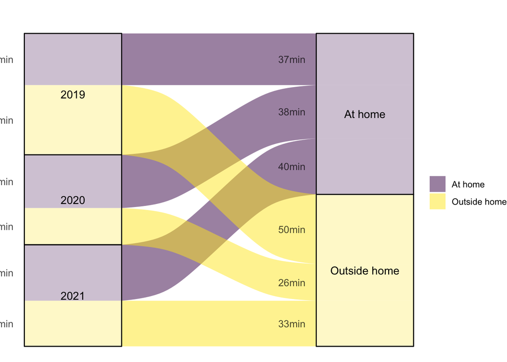

```r
ggplot(al, aes(axis1 = year, axis2 = group, y = engage)) +
   geom_alluvium(aes(fill =group)) +
  geom_stratum( alpha = .5) +
scale_x_discrete(expand = c(.1, .1)) +
  scale_fill_viridis_d() +
  theme_minimal() +
 geom_text(stat = "stratum",
            aes(label = after_stat(stratum))) +
  scale_x_discrete(limits = c("year", "group"),
                   expand = c(0.15, 0.05)) +
  theme_void()+
   geom_text(aes(label = paste0(round(engage, 0), "min")), stat = "flow", nudge_x = -.25, alpha=0.7, size=3.5) +
  labs(title = "",
      # subtitle = "",
       x = NULL,
       fill = NULL,
       y = "")  # the \n adds a line break
```

# Line plots

Here we present a line plot to show how older adults use their time before and over the course of the pandemic. Note, due to the impact of the pandemic, data collection was paused from March 18, 2020, to May 9, 2020. We actually have a missing month for April 2020. Time spent outside home plummeted since the national lockdown.

```r
df<-ATUS%>%filter(age>59)%>%select("engage_h","engage_nh", "year", "race4", "weight", "month", "caseid", "female", "edu4" )%>%mutate(ym=format(lubridate::ym(paste0(year,month)), "%Y.%m"), eg=engage_h+engage_nh)
df$ym<-as.factor(df$ym)

library(survey)
sydata<-svydesign(id=~caseid, weights=~weight, data=df)

datline<-svyby(~engage_h + engage_nh+eg, ~ym,   sydata,svymean,  keep.var=TRUE)
names(datline)<-c("ym", "engage.1", "engage.2","engage.3", "se.1","se.2", "se.3")

line<-reshape(datline,
        direction = "long",
        idvar = "ym",       # i
        timevar = "group",  # j
        varying = c("engage.1", "engage.2", "engage.3","se.1","se.2","se.3"))
line$group<-factor(line$group, levels=c(1,2,3), labels=c("In home", "Out-of-home", "Total"))

line$upper<-line$engage+1.96*line$se
line$lower<-line$engage-1.96*line$se
line$time<-seq(1,nrow(line), 1)
```

```r
lplot<-ggplot(data=line, aes(x = ym, y = engage, color= group, group= group)) +
  #geom_rect(aes(xmin='2019.01',
                 # xmax = '2019.12',
                 # ymin = -Inf,
                #   ymax = Inf),  fill = "grey85",  alpha = 0.03) +
    #geom_rect(aes(xmin='2021.01',
               # xmax = '2021.12',
               #   ymin = -Inf,
               #   ymax = Inf),  fill = "grey85",  alpha = 0.03) +
  geom_line( size=0.5) +
  geom_point(  size = 1.5)+
 #geom_ribbon(aes(ymin=lower, ymax=upper), linetype=2, alpha=0.01)+

  geom_vline(xintercept = "2020.05",
               colour = "grey40",
               linetype = 2)+ # vertical line
 # geom_vline(xintercept = "2021.08",
              # colour = "grey40",
               #linetype = 2)+ # vertical line
  labs( x= "Month" , y= 'Time (min)',title= "", color="", type="", size=8)+
  hrbrthemes::theme_ipsum()+
  theme(axis.text.x = element_text(angle = 90, vjust=0.5, hjust=1, size=5), legend.title = element_blank(),legend.text = element_text(size=8))+
  scale_color_manual(values = c("#D16103", "#293352","#9999CC")) +
  coord_cartesian(ylim = c(0,100))
```

Here `gganimate` gives us a nice animation plot.

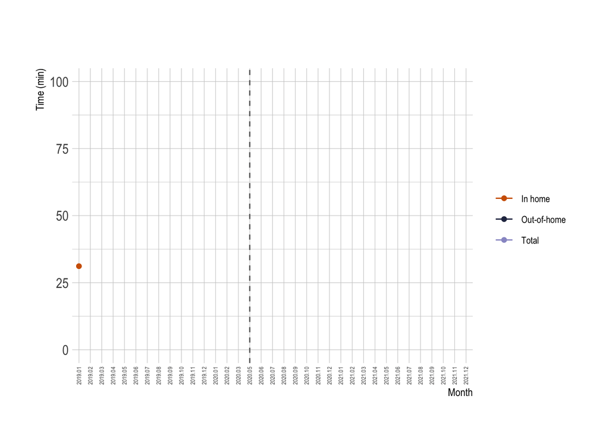

```r
library(gganimate)


lplot+geom_point() +
  transition_reveal(time)
```

# Line plot by race

```r
df<-ATUS%>%filter(age>59 )%>%select("engage_h","engage_nh", "year", "race4", "weight", "month", "caseid", "race4")
df<-df%>%mutate(ym=format(lubridate::ym(paste0(df$year,df$month)), "%Y.%m"))
df$ym<-as.factor(df$ym)

library(survey)
sydata<-svydesign(id=~caseid, weights=~weight, data=df)


datline<-svyby(~engage_h + engage_nh, ~ym+race4,   sydata,svymean,  keep.var=TRUE)
names(datline)<-c("ym", "race4",  "engage.1", "engage.2", "se.1","se.2")

line<-reshape2::melt(datline, id.vars =c("ym", "race4"), measure.vars= c("engage.1", "engage.2"))

line$group<-factor(line$variable, levels=c("engage.1","engage.2"), labels=c("At home", "Outside home"))

line$race4<-factor(line$race4, levels=c(1:4), labels=c("White", "Black", "Hispanic", "Other"))
```

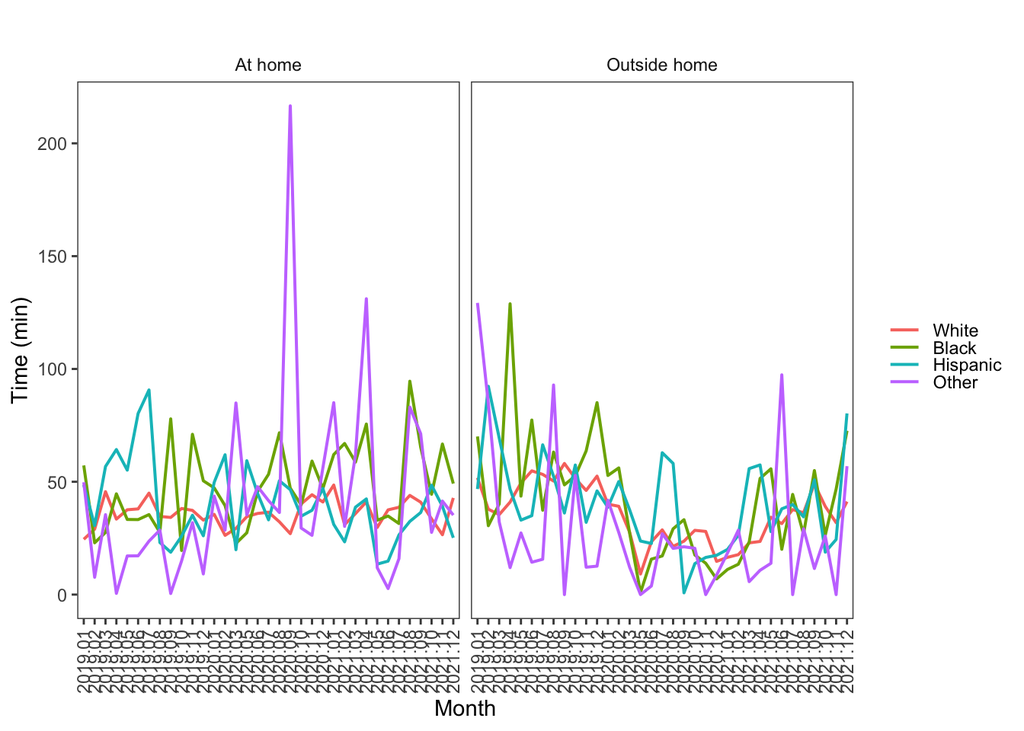

```r
ggplot(data=line, aes(x = ym, y = value, color= factor(race4),group= factor(race4))) +
  geom_line(size=0.7) +
  #geom_ribbon(aes(ymin=lower, ymax=upper), linetype=2, alpha=0.01)+
  labs( x= "Month" , y= 'Time (min)',title= "", color="", type="")+
  theme_article()+
  theme(axis.text.x = element_text(angle = 90, vjust=0.5, hjust=1), legend.title = element_blank())+facet_wrap(~group)
```

# Bar charts

The pattern for out of home engagement is consistent across racial groups. We see a decline in 2020 and a recovery in 2021. The magnitude differs for different racial groups. In home activity time seems increases for Blacks and Other racial groups (almost Asian), But not for Whites or Hispanics.

```r
datb<-svyby(~engage_h + engage_nh, ~year+race4,   sydata,svymean,  keep.var=TRUE)
```

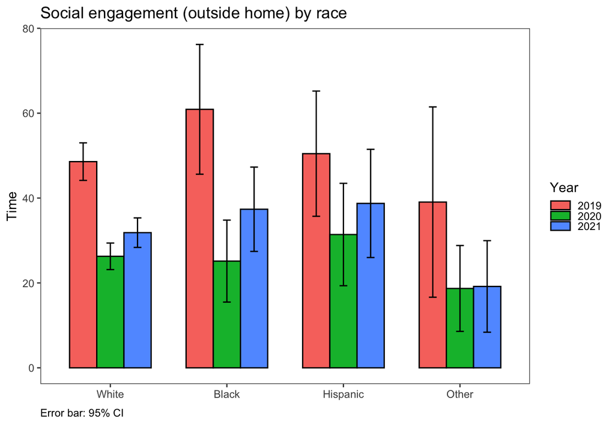

```r
ggplot(datb, aes(x = factor(race4), y =engage_nh, fill=factor(year))) +
  geom_bar(stat="identity", color="black", width = 0.7,
           position=position_dodge(0.7)) +
 # scale_fill_manual(values=c("grey30", "grey42", "grey76"))+
  geom_errorbar(aes(ymin=engage_nh-1.96*se.engage_nh, ymax=engage_nh+1.96*se.engage_nh), width=.2,
                 position=position_dodge(0.7))+ theme_article()+
  #geom_text(aes(label = round(engage_nh, 1)), size = 3, position = position_dodge(0.7), vjust = -0.5)+
   theme(plot.caption = element_text(hjust = 0, vjust=7))+
      #scale_x_discrete(labels= c("Male", "Female" ))+
      #scale_x_discrete(labels= c(">HS", "HS", "Some college", "college+"))+
    scale_x_discrete(labels= c("White", "Black", "Hispanic", "Other"))+
  labs( x= " " , y= "Time",title= "Social engagement (outside home) by race", fill="Year", caption = "Error bar: 95% CI")
```

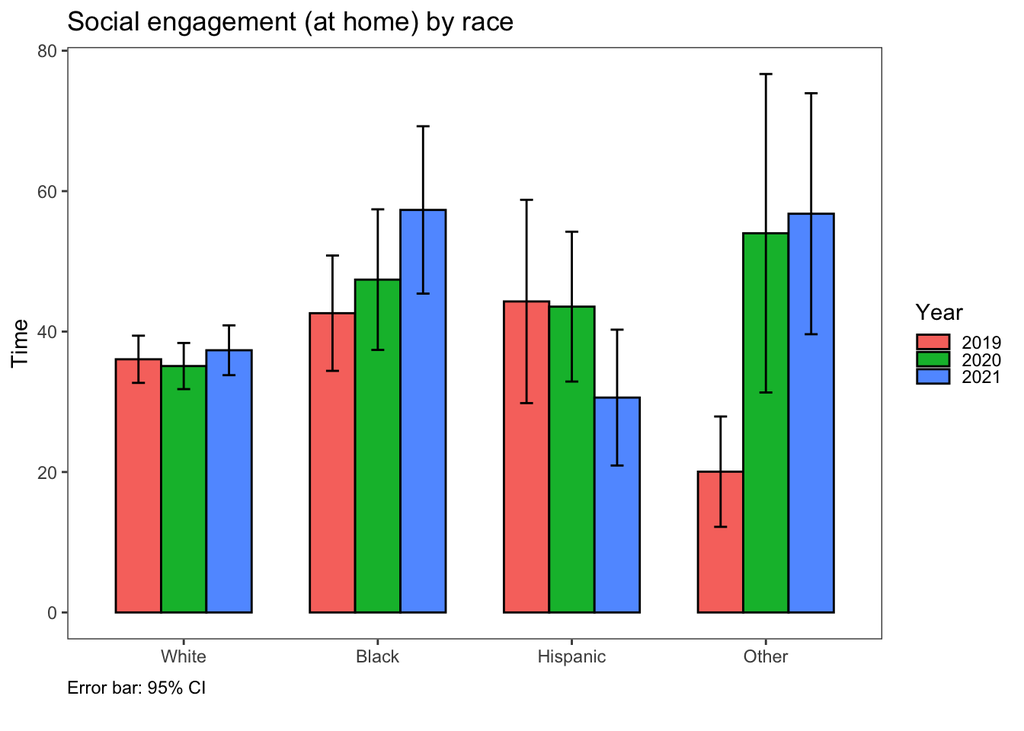

```r
ggplot(datb, aes(x = factor(race4), y =engage_h, fill=factor(year))) +
  geom_bar(stat="identity", color="black", width = 0.7,
           position=position_dodge(0.7)) +
  #scale_fill_manual(values=c("grey30", "grey42", "grey76"))+
  geom_errorbar(aes(ymin=engage_h-1.96*se.engage_h, ymax=engage_h+1.96*se.engage_h), width=.2,
                 position=position_dodge(0.7))+ theme_article()+
   theme(plot.caption = element_text(hjust = 0, vjust=7))+
    #scale_x_discrete(labels= c("Male", "Female" ))+
   #scale_x_discrete(labels= c(">HS", "HS", "Some college", "college+"))+
    scale_x_discrete(labels= c("White", "Black", "Hispanic", "Other"))+
  labs( x= " " , y= "Time",title= "Social engagement (at home) by race", fill="Year", caption = "Error bar: 95% CI")
```

# Boxplots

```r
ATUS<-read.dta("/Users/jiaoyu/Documents/Ph.D/projects/ATUS/data/atus_R.dta",convert.factors = T)
df<-ATUS%>%filter(age>59)%>%select("p_h","p_nh", "year", "race4")%>%mutate(year=as.factor(year))

databox<-reshape2::melt(df, id.vars = c("year", "race4"))%>%mutate(group=factor(variable, levels=c("p_h","p_nh"), labels=c("At home", "Outside home")))
```

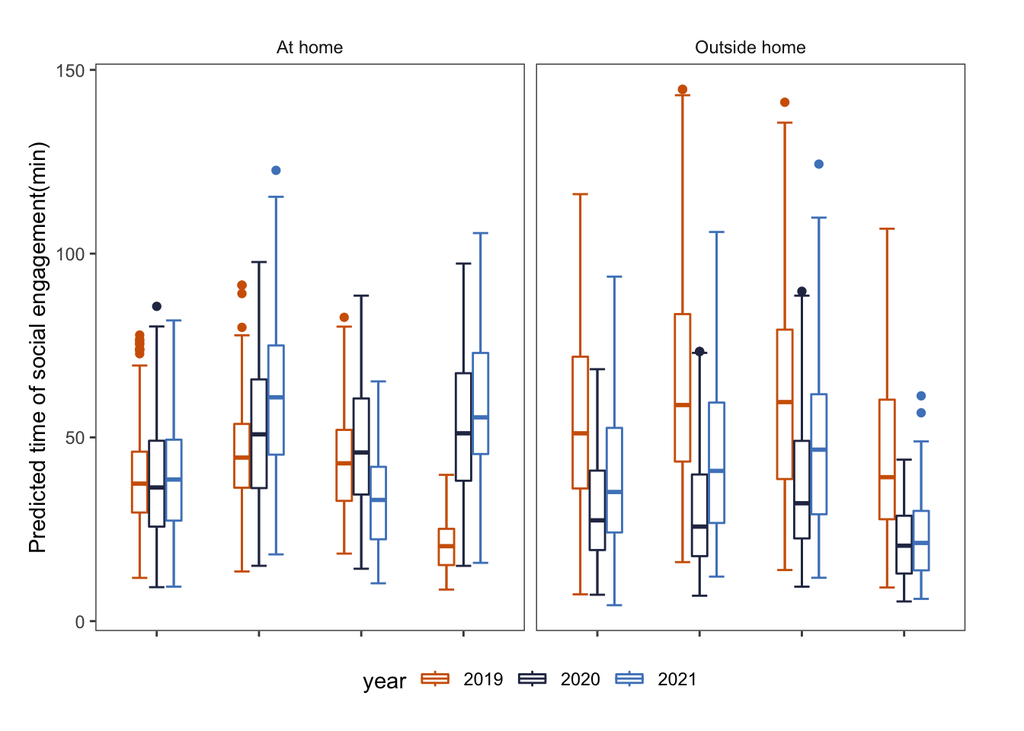

```r
ggplot(databox, aes(x = race4, y =value, color= year))+
   stat_boxplot(geom = "errorbar", width = 0.5)+
   geom_boxplot(width=0.5)+facet_wrap(~group)+
  labs( x= "" , y= "Predicted time of social engagement(min)",title= NULL, fill="")+theme_article()+ theme(legend.position = "bottom")+
  scale_color_manual(values = c("#D16103", "#293352","#4E84C4")) +
  theme(plot.margin = unit(c(1, 2, 1, 1), "lines"),
        axis.title.x = element_blank(),
        axis.text.x = element_blank(),
        panel.grid.major.x = element_blank(),
        panel.grid.minor.x = element_blank())
```

```r
library(readxl)    ## read multiple datas in one excel
read_excel_allsheets <- function(filename, tibble = FALSE) {
    # I prefer straight data.frames
    # but if you like tidyverse tibbles (the default with read_excel)
    # then just pass tibble = TRUE
    sheets <- readxl::excel_sheets(filename)
    x <- lapply(sheets, function(X) readxl::read_excel(filename, sheet = X))
    if(!tibble) x <- lapply(x, as.data.frame)
    names(x) <- sheets
    x
}

mysheets <- read_excel_allsheets("/Users/jiaoyu/Documents/Ph.D/projects/ATUS/data/activity_change.xlsx")

library(scales)
datawater<-mysheets$Sheet1
datachange<-mysheets$Sheet2
datachange<-datachange%>%mutate(per=percent(as.numeric(datachange$percent)), per=as.numeric(datachange$percent))
```

# waterfall plots

Waterfall plots can easily show changes across years. Here, we show how time spent on social and leisure activities changeS during the pandemic at in-home and out-of-home settings.

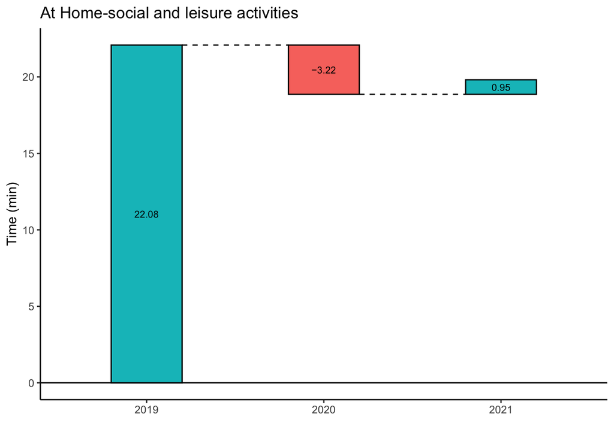

```r
library(waterfalls)
water<-datawater%>%filter(activity=="Social and leisure activities" & place== "home")%>%select(year, value)%>%round(., 2)
water$year<-factor(water$year, levels= c(2019, 2020, 2021))
waterfall(water, put_rect_text_outside_when_value_below=0.5, rect_width = 0.4)+
  theme_classic()+
  labs(title="At Home-social and leisure activities",x = '', y = 'Time (min)')
```

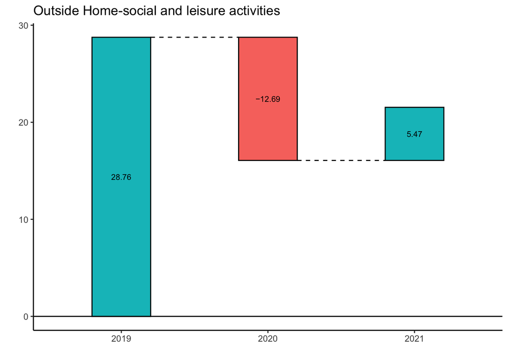

```r
water<-datawater%>%filter(activity=="Social and leisure activities" & place== "nhome")%>%select(year, value)%>% round(., 2)
water$year<-factor(water$year, levels= c (2019, 2020, 2021))
waterfall(water, put_rect_text_outside_when_value_below=0.5,rect_width = 0.4, fill_colours=c("#D16103","#4E84C4"))+
  theme_classic()+
  labs(title="Outside Home-social and leisure activities",x = '', y = '')
```

# Lollipop plot

Another way to show changes across time using lollipop plots. Most in-home activity time changes positively, i.e. increases in time spent at home. Most out-of-home activity time chanegs negatively, i.e. decreases in time spent outside home.

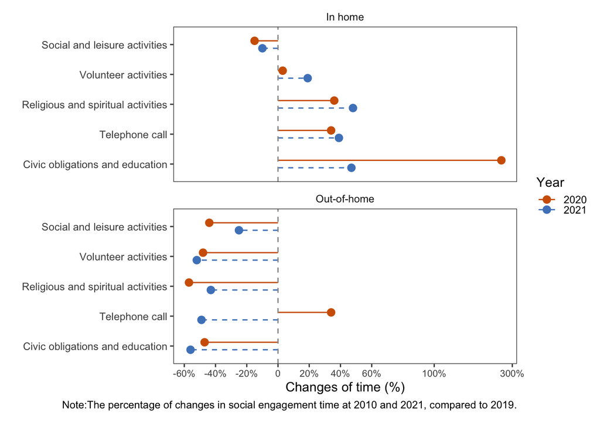

```r
library(ggstance)
datachange$year<-factor(datachange$year, levels=c(2020, 2021), labels=c(2020, 2021))

datachange$activity<-factor(datachange$activity, levels=c("Civic obligations and education", "Telephone call", "Religious and spiritual activities","Volunteer activities","Social and leisure activities"), labels=c("Civic obligations and education", "Telephone call", "Religious and spiritual activities","Volunteer activities","Social and leisure activities"))


ggplot(datachange, aes(y=activity, x=percent*100, colour=factor(year))) +
  ggstance::geom_pointrangeh(aes(xmin=0, xmax=percent*100), position=position_dodgev(height=-0.5),
 linetype=ifelse(datachange$type=="p", "dashed", "solid")
                             )+
  geom_vline(xintercept = 0,
               colour = "grey60",
               linetype = 2)+ # vertical line
facet_wrap(~place,ncol=1)+
 theme_article()+
  labs(color = "Year", x= "Changes of time (%)", y ="",caption = "Note:The percentage of changes in social engagement time at 2010 and 2021, compared to 2019.\n ")+
 scale_color_manual(values=c("#D16103","#4E84C4"))+
  scale_x_continuous(breaks=c(-80,-60, -40, -20, 0, 20, 40, 60, 100, 150),
                       labels=c( "-80", "-60%", "-40%","-20%" , "0", "20%", "40%", "60%","100%", "300%"))+theme(axis.text.x = element_text(size=8))
```

# Time Use Maps

```r
#map by states
library(mapdata)
library(viridis)
library(ggthemes)
library(RColorBrewer)

ATUS<-read.dta("/Users/jiaoyu/Documents/Ph.D/projects/ATUS/data/atus_R.dta",convert.factors = T)
states<-map_data("state")

df<-ATUS%>%filter(age>59)%>%select("engage_h","engage_nh","statefip", "weight", "caseid", "year")

df<-ATUS%>%select("engage_h","engage_nh","statefip", "weight", "caseid", "year")

colnames(df)[3]<-"region"

sydata<-svydesign(id=~caseid, weights=~weight, data=df)

map1<-svyby(~engage_h + engage_nh, ~region+year,   sydata,svymean,  keep.var=TRUE)


map19<-map1%>%filter(year==2019)
map20<-map1%>%filter(year==2020)

MergedStates19 <-states%>%left_join(map19, by = "region")
MergedStates20 <-states%>%left_join(map20, by = "region")
```

[figure not shown]

```r
ggplot()+
  geom_polygon( data=MergedStates19,
          aes(x=long, y=lat, group=group, fill = engage_nh))+
scale_color_viridis()+
theme_map() +
   #scale_fill_viridis(trans = "reverse")
scale_fill_distiller(palette = "RdYlBu", name = "At home")+labs(title= "Social engagement outside home by states-2019")
```

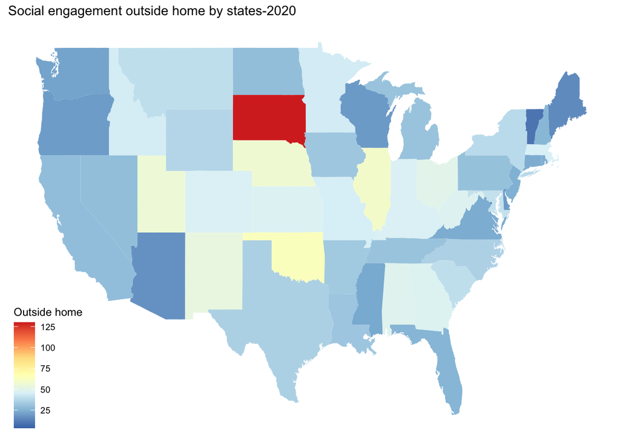

```r
ggplot()+
  geom_polygon( data=MergedStates20,
          aes(x=long, y=lat, group=group, fill = engage_nh))+
scale_color_viridis()+
theme_map() +
   #scale_fill_viridis(trans = "reverse")
scale_fill_distiller(palette = "RdYlBu", name = "Outside home")+labs(title= "Social engagement outside home by states-2020")
```